# Final Project

Celeste Kim

9/2/2019

### Data Science 250 Midterm Presentation

### Data

- https://catalog.data.gov/dataset/collisions
- Data set regarding all collisions from 2004 - present in the city of Seattle

### Initial Questions

- To what degree do driving conditions(road condition, light condition, weather) affect the chances of collisions?
- Do some parts of the road(intersection, block, alley) have more tendency to cause collisions?
- How has different variables of collisions changed over the time period of the data set?

## - How are driving conditions(road condition, light condition, weather) associated with the severity of collisions?

```
## # A tibble: 171,692 x 2
##    ROADCOND SEVERITYCODE
##    <fct>    <fct>
##  1 Dry      1
##  2 Dry      1
##  3 Wet      1
##  4 Wet      1
##  5 Dry      1
##  6 Dry      1
##  7 Wet      2
##  8 Dry      1
##  9 Dry      2
## 10 Dry      1
## # ... with 171,682 more rows
```

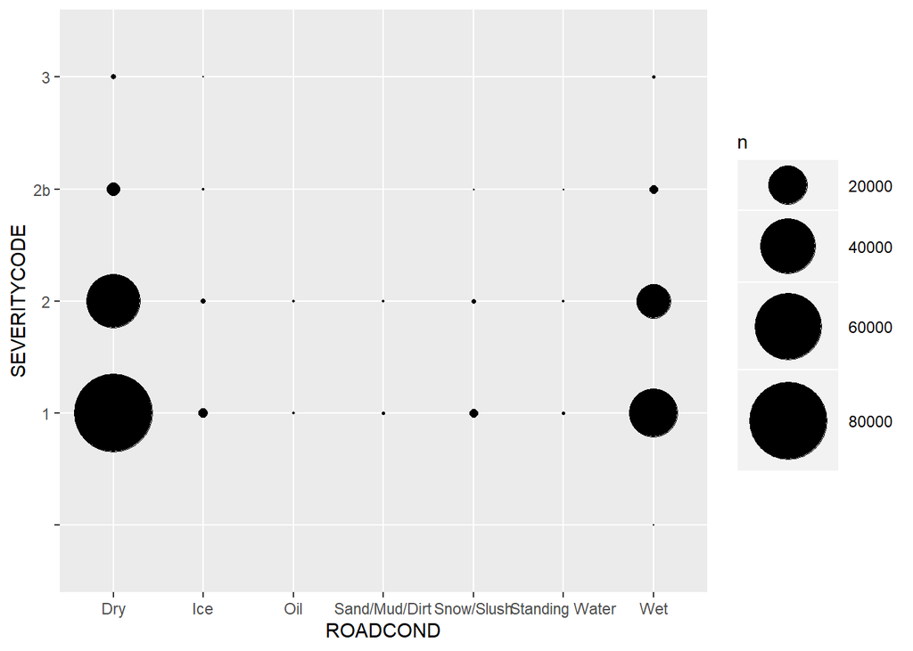

```
## # A tibble: 173,019 x 2
##    LIGHTCOND               SEVERITYCODE
##    <fct>                   <fct>
##  1 Daylight                1
##  2 Daylight                1
##  3 Dark - Street Lights On 1
##  4 Dark - Street Lights On 1
##  5 Dark - Street Lights On 1
##  6 Daylight                2
##  7 Daylight                1
##  8 Daylight                2
##  9 Daylight                1
## 10 Dark - Street Lights On 2
## # ... with 173,009 more rows
```

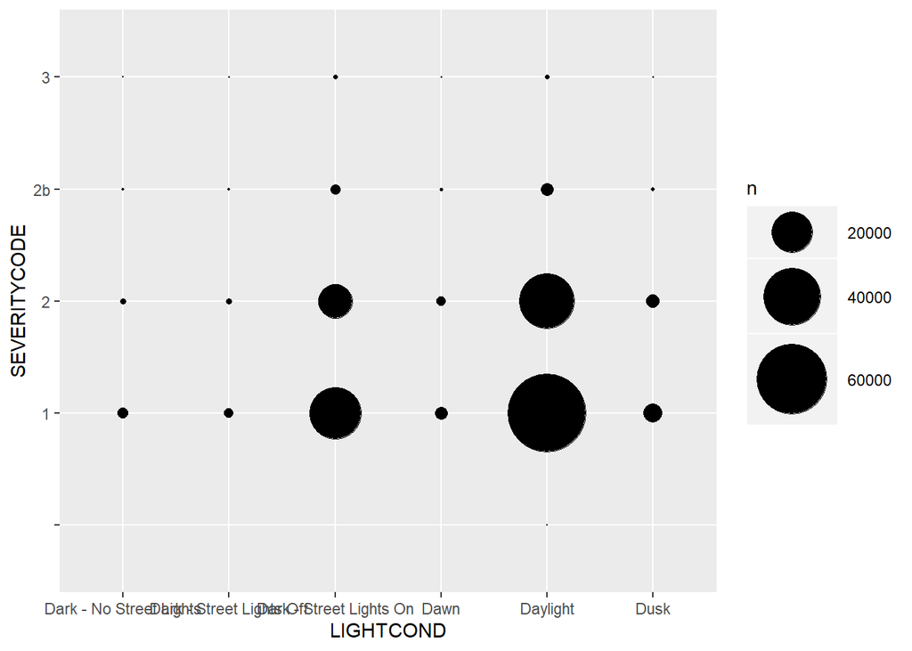

Light Conditions(In Order)

- Dark - No Street Lights
- Dark - Street Lights Off
- Dark - Stree Lights On
- Dawn
- Daylight
- Dusk

```
## # A tibble: 170,881 x 2
##    WEATHER                SEVERITYCODE
##    <fct>                  <fct>
##  1 Clear or Partly Cloudy 1
##  2 Overcast               1
##  3 Snowing                1
##  4 Raining                1
##  5 Clear or Partly Cloudy 1
##  6 Overcast               1
##  7 Overcast               2
##  8 Overcast               1
##  9 Clear or Partly Cloudy 2
## 10 Overcast               1
## # ... with 170,871 more rows
```

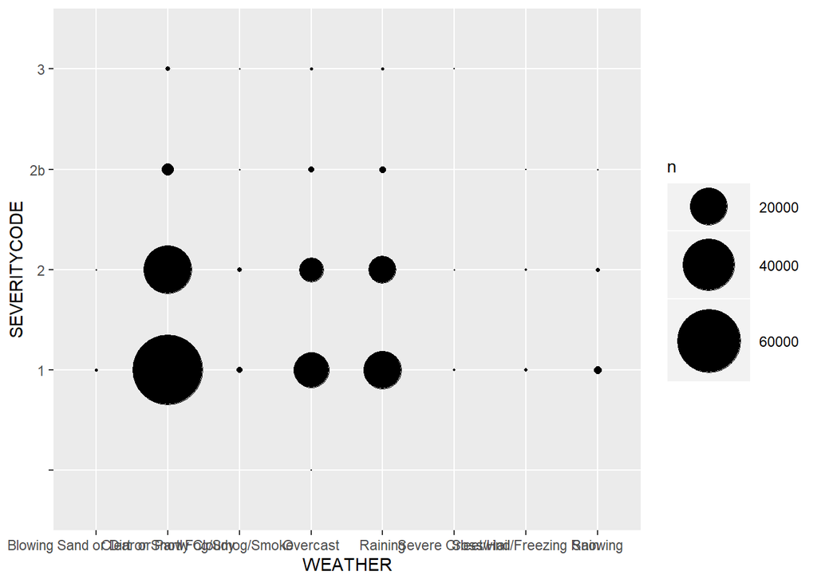

Weathers(In Order)

- Blowing Sand or Dirt Snow
- Clear or Partly Cloudy
- Fog/Smog/Smoke
- Overcast
- Raining
- Severe Crosswind
- Sleet/Hail/Freezing Rain
- Snowing

## - How is the the type of the road associated with the severity of collisions? (Trevor’s Suggestion)

```
## # A tibble: 3 x 5
##   ADDRTYPE     fatality_rate serious_injury_rate injury_rate prop_dmg_rate
##   <fct>                <dbl>               <dbl>       <dbl>         <dbl>
## 1 Alley                0                    1.09        10.8          88.1
## 2 Block                0.147                1.17        23.4          75.3
## 3 Intersection         0.226                2.32        41.6          55.8
```

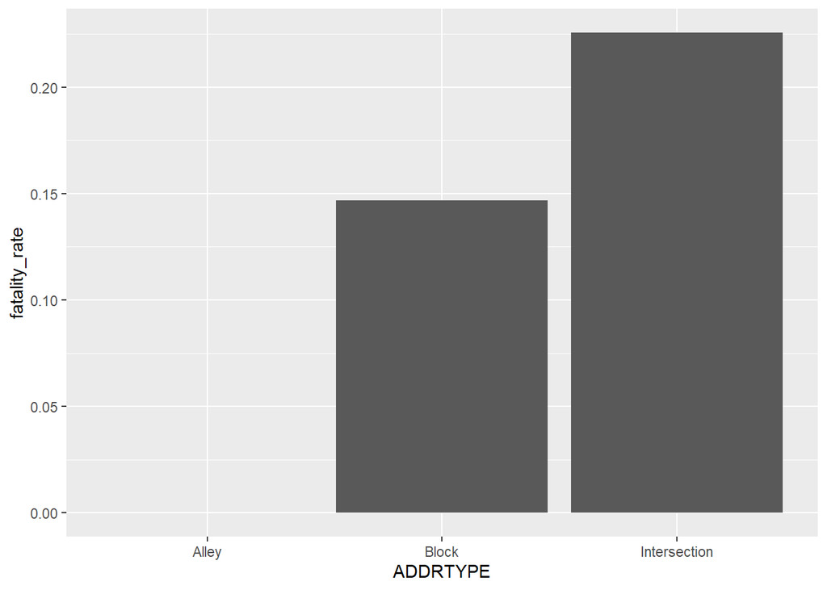

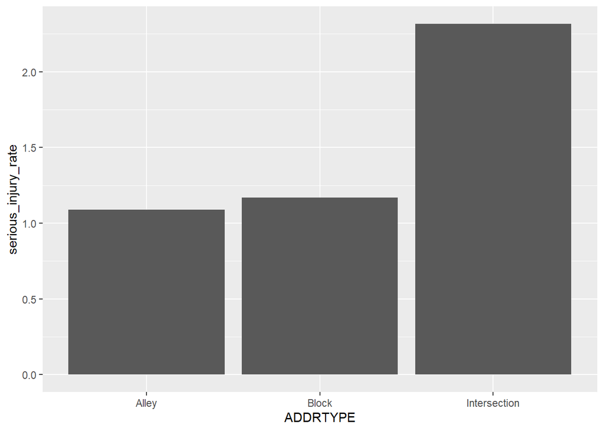

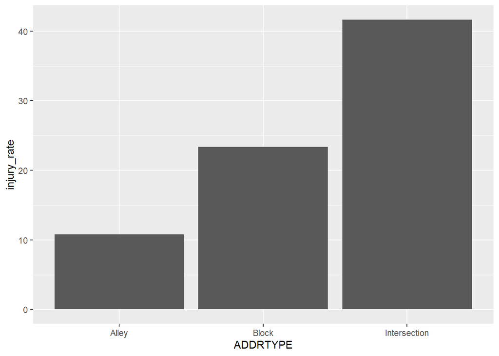

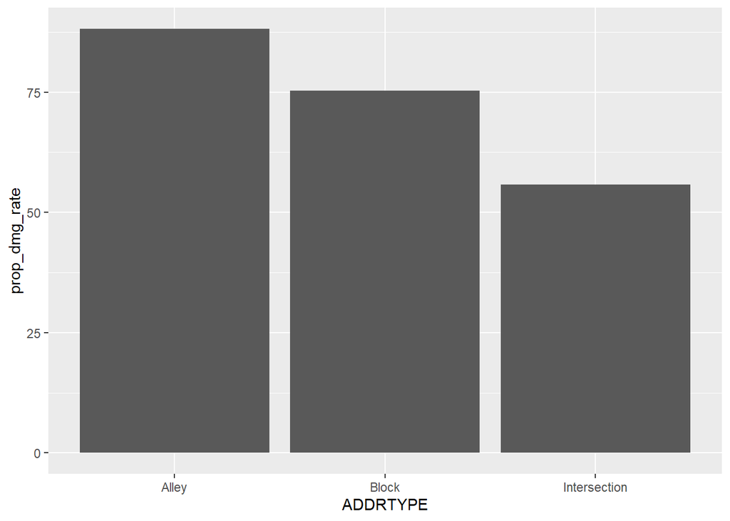

## - How has different variables of collisions changed over the time period of the data set? (Not Changed)

```
## # A tibble: 212,363 x 4
##     year month  date SEVERITYCODE
##    <int> <int> <int> <fct>
##  1  2003    10     6 0
##  2  2004     1     1 2
##  3  2004     1     1 1
##  4  2004     1     1 2
##  5  2004     1     1 1
##  6  2004     1     1 1
##  7  2004     1     1 2
##  8  2004     1     1 1
##  9  2004     1     1 2
## 10  2004     1     1 2
## # ... with 212,353 more rows
```

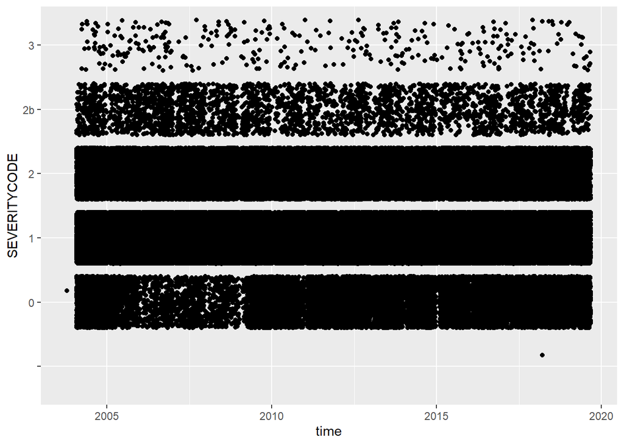

## Difficulties

- Thankfully, most of the data set was tidy and did not require a lot of data wrangling
  - Examples of difficulties, however, included variable called INCDATE, which lumped together year, month, date, and an unrecognizable string together, which I had to use the “separate()” function to tidy
- Still having difficulties finding a method to create a visual incorporating the map of Seattle and markers indicating the frequency of collisions
- A lot of Unknown/implicitly missing values that require a lot of filtering
- Too much data (e.g. time vs severity)

## Looking Forward

- Continue research with the visual incorporating the map of Seattle and markers indicating the frequency of collisions
- Analyze data to potentially find causation, not just association
- Compare more variables with time